```python
from IPython.display import Image
```

# Logistic Regression Theory

## Classification

Classification applies to cases where we are trying to predict discrete outcomes that might not be numeric. Examples include:

- Whether a person purchases a product or not
- Who an individual will vote for
- What outcome a patient has following a surgery

In cases where we are considering only two possible outcomes, logistic regression is very useful.

- Yes, it is a regression method! We will go into how it (and any regression method) can be turned into a classification tool

## Logistic Regression Introduction

Logistic regression, also known as logit regression, is a tool for modeling the probability of a certain class existing (e.x. yes or no).

- Binomial Logistic Regression: Applies to one class with two outcomes
- Multinomial Regression: Applies to one class with more than two outcomes

We will start with binomial logistic regression, which can be shortened to just saying logistic regression (yes, another confusing part of the wording). In other words, if someone is discussing logistic regression, assume it is binomial unless otherwise specified!

Logistic regression models (also known as a logit model) the probability between 0 and 1.

- To turn a logit model into a classification tool, set probability thresholds. E.x. "If the output is greater than or equal to 0.6, return YES, else return NO"
- It is most common for the threshold to be set at 0.5, but it can vary
- Linear regression is not appropriate for this as the values of a linear regression can extend outside the range $[0,1]$

**The key idea is to model the probability of an outcome and define at what thresholds the outcome is decided.**

## Binomial Logistic Regression

Whenever we think of a class with two outcomes, we view success as "1" and failure as "0":

- E.x. If a person purchases X, mark as 1, else mark as 0

Logistic regression estimates the log-odds of success (i.e. $q(X)=Pr(Y=1|X)$) based on a linear combination of the predictors:

- $ln(\frac{q(X)}{1-q(X)}) = \beta_0 + \beta_1X_1 + \beta_2X_2 + ... + \beta_pX_p$

This can also be written as:

- $q(X)=Pr(Y=1|X) = \frac{exp(\beta_0 + \beta_1X_1 + \beta_2X_2 + ... + \beta_pX_p)}{1 + exp(\beta_0 + \beta_1X_1 + \beta_2X_2 + ... + \beta_pX_p)}$

The notation $Pr(Y=1|X)$ can be read as the "probability of Y = 1 (i.e. success) given X."

- Y is the dependent variable
- X describes the independent variables

Another way to view this is we are applying the sigmoid function $p = \frac{1}{(1+e^{-y})}$ on the linear regression equation.

### Example Logistic Regression

```python
import numpy as np
import pandas as pd

hours = np.array([0.50,0.75,1.00,1.25,1.5,1.75,1.75,2,2.25,2.50,2.75,3.00,3.25,3.50,4.00,4.25,4.50,4.75,5,5.50])
pass_indicator = np.array([0,0,0,0,0,0,1,0,1,0,1,0,1,0,1,1,1,1,1,1])

df = pd.DataFrame({'Hours': hours, 'Pass': pass_indicator})
df
```

|  | Hours | Pass |
| --- | --- | --- |
| 0 | 0.50 | 0 |
| 1 | 0.75 | 0 |
| 2 | 1.00 | 0 |
| 3 | 1.25 | 0 |
| 4 | 1.50 | 0 |
| 5 | 1.75 | 0 |
| 6 | 1.75 | 1 |
| 7 | 2.00 | 0 |
| 8 | 2.25 | 1 |
| 9 | 2.50 | 0 |
| 10 | 2.75 | 1 |
| 11 | 3.00 | 0 |
| 12 | 3.25 | 1 |
| 13 | 3.50 | 0 |
| 14 | 4.00 | 1 |
| 15 | 4.25 | 1 |
| 16 | 4.50 | 1 |
| 17 | 4.75 | 1 |
| 18 | 5.00 | 1 |
| 19 | 5.50 | 1 |

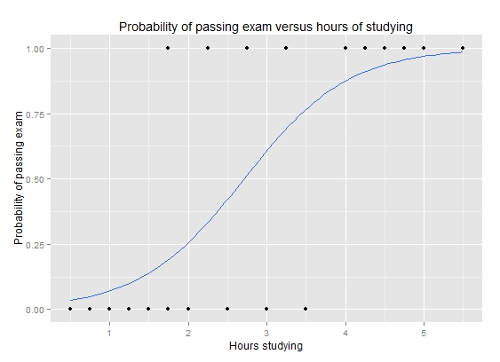

```python
Image("img/logistic_regression_example.jpeg")
```

The above data and graph is from Wikipedia.

- The black data points represent the actual outcomes
- As seen, the logistic regression plots the probability of a student passing from 0 to 1
- This logistic regression accurately reflects the outcomes -- at the start of the curve are mostly "zero" outcomes which have very low probability of being 1. At the end of the curve, the "one" outcomes have a very high probability. This makes sense as more hours studied should result in a greater likelihood of passing.
- Logistic regression generally takes on an S-shape

### Maximum Likelihood Estimation and Deviance

The $\beta$ values are estimated by selecting the $\hat{\beta_0}, \hat{\beta_1}, ..., \hat{\beta_p}$ values that maximize the likelihood function:

- $\prod_{i=1}^{n} f(y_i|x_i)$

This is basically the cumulative product of each outcome $y_i$ given $x_i$ and can be rewritten as:

- $\prod_{i=1}^{n}(q(x_i))^{y_i}(1-q(x_i))^{1-y_i}$

which is equivalent to:

- = $\prod_{i=1}^{n} [\frac{exp(\beta_0+\beta^Tx_i)}{1+exp(\beta_0+\beta^Tx_i)}]^{y_i} \cdot [\frac{1}{1+exp(\beta_0+\beta^Tx_i)}]^{1-y_i}$

In case you are unfamiliar with the notation:

- $\beta_0$ refers to the intercept as before
- $\beta$ refers to $\beta_1, ..., \beta_p$ -- this is a vector of $\beta$ values
- $\beta^T$ refers to taking the transpose of the $\beta$ values, so that when it is multipled by $x_i$ the dimensions work out correctly
- It is good to know, but OK if you are not entirely familiar with this as it dives more into linear algebra

Why do we use product operator ($\prod$) instead of a summation ($\sum$)?

- An intuitive way to view this is that likelihood is the same as probability, which is between 0 and 1
- The maximum probability that can exist is 1 (by definition)
- Suppose we have three rows in our dataset, each with probability 1
- The maximum likelihood estimation (MLE) should be $1\cdot1\cdot1=1$ not $1+1+1=3$

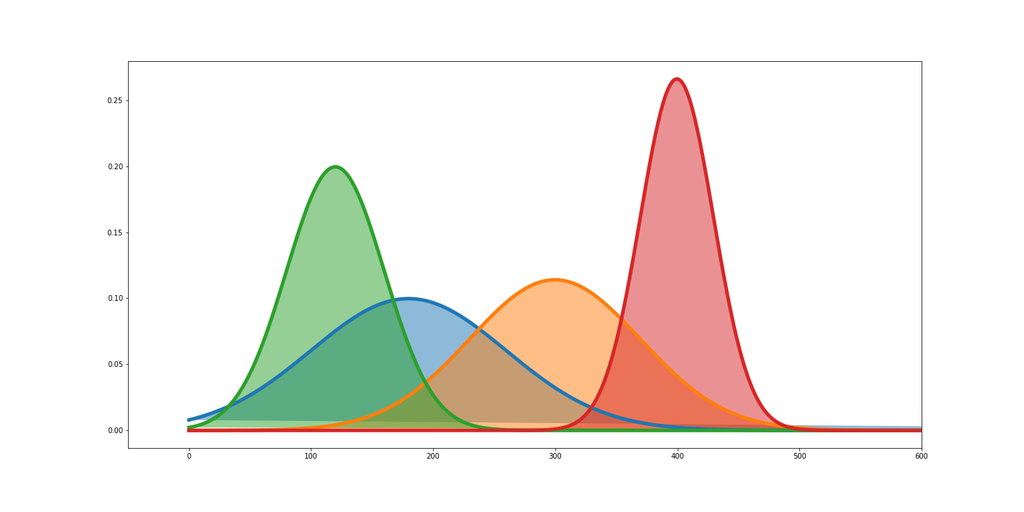

```python
Image("img/mle.png")
```

Source: Towards Data Science

The Maximum Likelihood Estimation is like asking -- "which of these curves are most likely to fit our data?"

Maximizing the likelihood function is equivalent ot minimizing the **deviance**, which is the negative log of the likelihood:

- $D=-[sum_{i=1}^{n}y_ilog(q(x_i))+sum_{i=1}^{n}(1-y_i)log(1-q(x_i))]$

where $q(x_i)=\frac{exp(\hat{\beta_0} + \hat{\beta_1x_{i1}}+...+\hat{\beta_px_{ip}})}{(1+exp(\hat{\beta_0} + \hat{\beta_1x_{i1}}+...+\hat{\beta_px_{ip}}))}$

We usually focus on minimizing deviance as it is a significantly less expensive question to solve. The real significance of taking the negative log of the likelihood is it turns the equation into a **convex optimization** problem, which has much better time efficiency.

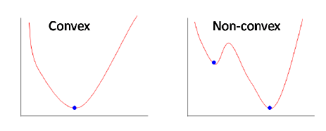

```python
Image("img/convex_non-convex.png")
```

Source: Quora

In a convex function, there is only one optimum -- the global optimum. In a non-convex function, we can have local optimum (e.x. in the graph above there are two local minima).

### Using Logistic Regression for Classification

Remember that Logistic Regression provides a probability of success.

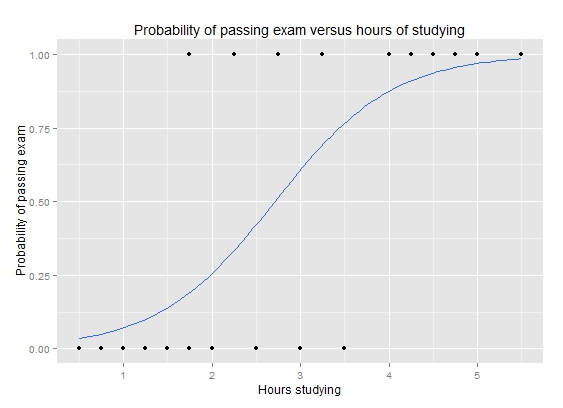

```python
Image("img/logistic_regression_example.jpeg")
```

The graph above is the plotted output of the function:

- $\hat{q}(x) = \frac{exp(\hat{\beta_0} + \hat{\beta_1x_{i1}}+...+\hat{\beta_px_{ip}})}{(1+exp(\hat{\beta_0} + \hat{\beta_1x_{i1}}+...+\hat{\beta_px_{ip}}))}$

How can we use $\hat{q}(x)$ to classify whether or not someone passed the exam?

- Set a threshold $\tau$ where if $\hat{q}(x)\geq\tau$, then label as a success, else a failure
- $\tau$ may be greater than or less than 0.5
- Selecting $\tau$ should be based on prediction metrics at different $\tau$ thresholds (e.x. what is the misclassification rate at $\tau = 0.5$ as opposed to $\tau = 0.2$?) -- reference **Model Selection and Assessment** to learn more about this

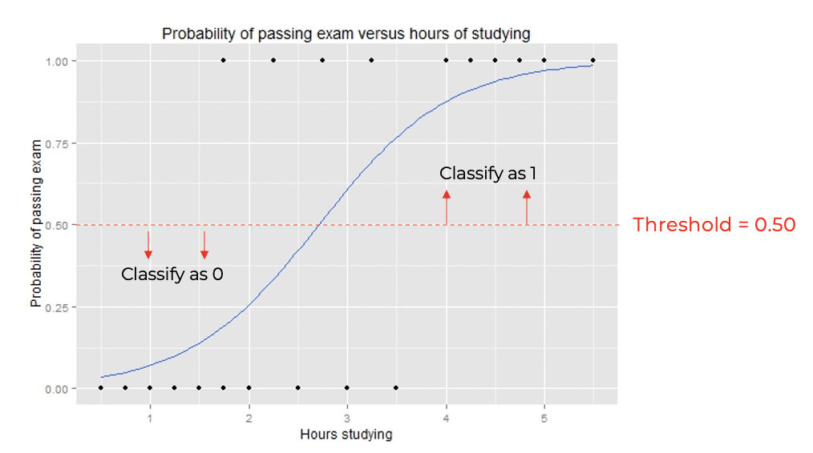

```python
Image("img/logistic_regression_threshold.png")
```

### Linear Regression as Classification

- The same threshold strategy can be applied to linear regression for classification purposes, though it usually is not as effective as logistic regression
- Why use linear regression?
  - Linear regression is more interpretable than logistic regression

## Multinomial Logistic Regression

Assume we have $K\geq2$ possible (unordered) outcomes $\{0,1,2,...,K-1\}$

- We go up to $K-1$ instead of up to $K$ because the absence of all other outcomes implies the last outcome $K$
- E.x. Suppose there are three outcomes: Yes, No, Maybe. We can define this as $Yes = (1,0)$, $No = (0,1)$ and $Maybe = (0,0)$.

We can describe the probability of each outcome $k = 1,...,K-1$ with:

- $q_k(x)=Pr(Y=k|X)=\frac{exp(\beta^{(k)\top}X)}{1+\sum_{l=1}^{K}exp(\beta^{\top}X)}$

For option 0:

- $q_0(x)=Pr(Y=k|X)=\frac{1}{1+\sum_{l=1}^{K}exp(\beta^{\top}X)}$

Option 0 is generally the default and serves as a normalization (i.e. $\beta^{(0)} = 0$)

## Quality of Logistic Regression

Since logistic regression is used for classification, you can apply accuracy as your out-of-sample metric within model selection and assessment.

## Choosing Predictors

We can use the same methods as outlined in the **Linear Regression** section.

Subset Selection

- Best Subset Selection
- Forward Stepwise Selection

Shrinkage

- Lasso
- Ridge
- Elastic Net

### Shrinkage

Recall we are trying to minimize deviance:

- $D=-[sum_{i=1}^{n}y_ilog(q(x_i))+sum_{i=1}^{n}(1-y_i)log(1-q(x_i))]$

where $q(x_i)=\frac{exp(\hat{\beta_0} + \hat{\beta_1x_{i1}}+...+\hat{\beta_px_{ip}})}{(1+exp(\hat{\beta_0} + \hat{\beta_1x_{i1}}+...+\hat{\beta_px_{ip}}))}$

To apply shrinkage penalties on $\beta$, just add the penalties to the deviance $D$.

- Ridge: $D + \lambda\sum_{j=1}^{p}\hat\beta_j^2$
- Lasso: $D + \lambda\sum_{j=1}^{p}\hat|\beta_j|$
- Elastic: $D + \lambda\sum_{j=1}^{p}((1-\alpha)\beta_j^2+\alpha|\beta_j|)$

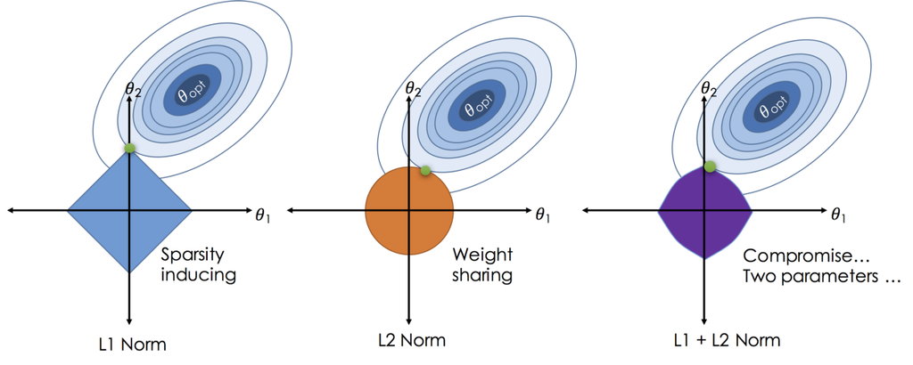

```python
Image("img/lasso_ridge_elastic_graphs.png")
```

## More Resources

[Logistic Regression Detailed Overview](https://towardsdatascience.com/logistic-regression-detailed-overview-46c4da4303bc)

[Logistic Regression for ML](https://machinelearningmastery.com/logistic-regression-for-machine-learning/)

Assumptions of Logistic Regression